# nfl_data_predictor_viz

Jeff

9/16/2021

## Load Dependencies

```r
# install.packages('devtools')
library(devtools)
install_github("AppliedDataSciencePartners/xgboostExplainer")
library(xgboost)
library(caret)
library(OptimalCutpoints)
library(xgboostExplainer)
library(pROC)
library(SHAPforxgboost)
library(randomForest)
library(rpart)
library(splitstackshape)
library(tidyverse)
library(Metrics)
library(elo)
```

## Creating the Play-by_Play Aggregations with a 15-Week Lag

```r
# Load Data

load("nfl_pbp_1999_2020.rda")
# Extract Games
pbp_2018_2020 <- pbp
games <- unique(pbp_2018_2020[, c(2,4,5,7,284,322, 323)])

# Drop games after week 15
pbp_use <- pbp_2018_2020[pbp_2018_2020$week <= 15,]


# Create index for play by play
pbp_index <- rep(NA, nrow(pbp_use))

for(i in 1:nrow(pbp_use)){
  if(pbp_use$season[i] == 1999){
    pbp_index[i] <- pbp_use$week[i]
  } else if (pbp_use$season[i] == 2000){
    pbp_index[i] <- pbp_use$week[i] + 15
  } else if (pbp_use$season[i] == 2001){
    pbp_index[i] <- pbp_use$week[i] + 30
  } else if (pbp_use$season[i] == 2002){
    pbp_index[i] <- pbp_use$week[i] + 45
  } else if (pbp_use$season[i] == 2003){
    pbp_index[i] <- pbp_use$week[i] + 60
  } else if (pbp_use$season[i] == 2004){
    pbp_index[i] <- pbp_use$week[i] + 75
  } else if (pbp_use$season[i] == 2005){
    pbp_index[i] <- pbp_use$week[i] + 90
  } else if (pbp_use$season[i] == 2006){
    pbp_index[i] <- pbp_use$week[i] + 105
  } else if (pbp_use$season[i] == 2007){
    pbp_index[i] <- pbp_use$week[i] + 120
  } else if (pbp_use$season[i] == 2008){
    pbp_index[i] <- pbp_use$week[i] + 135
  } else if (pbp_use$season[i] == 2009){
    pbp_index[i] <- pbp_use$week[i] + 150
  } else if (pbp_use$season[i] == 2010){
    pbp_index[i] <- pbp_use$week[i] + 165
  } else if (pbp_use$season[i] == 2011){
    pbp_index[i] <- pbp_use$week[i] + 180
  } else if (pbp_use$season[i] == 2012){
    pbp_index[i] <- pbp_use$week[i] + 195
  } else if (pbp_use$season[i] == 2013){
    pbp_index[i] <- pbp_use$week[i] + 210
  } else if (pbp_use$season[i] == 2014){
    pbp_index[i] <- pbp_use$week[i] + 225
  } else if (pbp_use$season[i] == 2015){
    pbp_index[i] <- pbp_use$week[i] + 240
  } else if (pbp_use$season[i] == 2016){
    pbp_index[i] <- pbp_use$week[i] + 255
  } else if (pbp_use$season[i] == 2017){
    pbp_index[i] <- pbp_use$week[i] + 270
  } else if (pbp_use$season[i] == 2018){
    pbp_index[i] <- pbp_use$week[i] + 300
  } else if (pbp_use$season[i] == 2019){
    pbp_index[i] <- pbp_use$week[i] + 315
  } else if (pbp_use$season[i] == 2020){
    pbp_index[i] <- pbp_use$week[i] + 330
  }
}

pbp_use$index <- pbp_index

games <- unique(pbp_use[, c(2,4,5,7,284,322, 323, 371)])

#### Define Functions for calculations

epa_calculator_off <- function(data, week_lag = 5, db){
  #'
  #' This function calculates the average EPA for each team for
  #' different play types.
  #'
  #' @param data The play-by-play dataset
  #' @param week_lag The number of weeks to use to calculate averages
  #' @param db The games to create stats for
  #'
  #' @return A data frame with the calculated values for each of the teams
  #'
  #'

  # Create empty columns to store results
  hrun_epa <- hrun_freq <- hpass_epa <- hpass_freq <- rep(NA, nrow(db))
  hgames <- rep(NA, nrow(db))

  arun_epa <- arun_freq <- apass_epa <- apass_freq <- rep(NA, nrow(db))
  agames <- rep(NA, nrow(db))

  # For each game
  for(i in 1:nrow(db)){
    # Calculate start index
    start_index <- max(1, db$index[i] - week_lag - 1)
    # Calculate end index
    end_index <- db$index[i] - 1
    # Extract plays involving teams of interest falling in window
    temp <- data[which(data$index > start_index &
                         data$index <= end_index &
                         data$posteam %in% c(db$home_team[i], db$away_team[i]) &
                         data$season == data$season[i]),]
    # If any such plays exist
    if(nrow(temp) >0 ){
      # Calculate total home run epa
      hrun_epa[i] <- sum(temp$epa[which(temp$play_type == "run" &
                                          temp$posteam == db$home_team[i])], na.rm = T)
      # Calculate total home run plays
      hrun_freq[i] <- nrow(temp[which(temp$play_type == "run" &
                                        temp$posteam == db$home_team[i]),])
      # Calculate total home pass epa
      hpass_epa[i] <- sum(temp$epa[which(temp$play_type == "pass" &
                                           temp$posteam == db$home_team[i])], na.rm = T)
      # Calculate total home pass plays
      hpass_freq[i] <- nrow(temp[which(temp$play_type == "pass" &
                                         temp$posteam == db$home_team[i]),])

      # Calculate total home number of games played
      hgames[i] <- length(unique(na.omit(temp$game_id[which(temp$posteam == db$home_team[i])])))

      # Calculate total away run epa
      arun_epa[i] <- sum(temp$epa[which(temp$play_type == "run" &
                                          temp$posteam == db$away_team[i])], na.rm = T)
      # Calculate total away run plays
      arun_freq[i] <- nrow(temp[which(temp$play_type == "run" &
                                        temp$posteam == db$away_team[i]),])
      # Calculate total away pass epa
      apass_epa[i] <- sum(temp$epa[which(temp$play_type == "pass" &
                                           temp$posteam == db$away_team[i])], na.rm = T)
      # Calculate total away pass plays
      apass_freq[i] <- nrow(temp[which(temp$play_type == "pass" &
                                         temp$posteam == db$away_team[i]),])

      # Calculate total number of away games played
      agames[i] <- length(unique(na.omit(temp$game_id[which(temp$posteam == db$away_team[i])])))
    }

  }
  # Calculate averages per play
  havg_run_epa <- hrun_epa/hrun_freq
  havg_pass_epa <- hpass_epa/hpass_freq

  # Calculate play type frequency per play
  hruns_per_game <- hrun_freq/hgames
  hpass_per_game <- hpass_freq/hgames

  # Calculate averages per play
  aavg_run_epa <- arun_epa/arun_freq
  aavg_pass_epa <- apass_epa/apass_freq

  # Calculate play type frequency per play
  aruns_per_game <- arun_freq/agames
  apass_per_game <- apass_freq/agames

  # Join results columns
  res_dat <- cbind.data.frame(hrun_epa, hrun_freq, hpass_epa, hpass_freq,
                              havg_run_epa, havg_pass_epa,  hgames,
                              hruns_per_game, hpass_per_game,
                              arun_epa, arun_freq, apass_epa, apass_freq,
                              aavg_run_epa, aavg_pass_epa,  agames,
                              aruns_per_game, apass_per_game)

  # Fill missing with 0
  #res_dat[is.na(res_dat)] <- 0
  # Return Results
  return(res_dat)
}



epa_calculator_def <- function(data, week_lag = 5, db){
  #'
  #' This function calculates the average EPA for each team for
  #' different play types.
  #'
  #' @param data The play-by-play dataset
  #' @param week_lag The number of weeks to use to calculate averages
  #' @param db The games to create stats for
  #'
  #' @return A data frame with the calculated values for each of the teams
  #'
  #'

  # Create empty columns to store results
  hrun_epa <- hrun_freq <- hpass_epa <- hpass_freq <- rep(NA, nrow(db))
  hgames <- rep(NA, nrow(db))

  arun_epa <- arun_freq <- apass_epa <- apass_freq <- rep(NA, nrow(db))
  agames <- rep(NA, nrow(db))

  # For each game
  for(i in 1:nrow(db)){
    # Calculate start index
    start_index <- max(1, db$index[i] - week_lag - 1)
    # Calculate end index
    end_index <- db$index[i] - 1
    # Extract plays involving teams of interest falling in window
    temp <- data[which(data$index > start_index &
                         data$index <= end_index &
                         data$defteam %in% c(db$home_team[i], db$away_team[i]) &
                         data$season == data$season[i]),]
    # If any such plays exist
    if(nrow(temp) >0 ){
      # Calculate total home run epa
      hrun_epa[i] <- sum(temp$epa[which(temp$play_type == "run" &
                                          temp$defteam == db$home_team[i])], na.rm = T)
      # Calculate total home run plays
      hrun_freq[i] <- nrow(temp[which(temp$play_type == "run" &
                                        temp$defteam == db$home_team[i]),])
      # Calculate total home pass epa
      hpass_epa[i] <- sum(temp$epa[which(temp$play_type == "pass" &
                                           temp$defteam == db$home_team[i])], na.rm = T)
      # Calculate total home pass plays
      hpass_freq[i] <- nrow(temp[which(temp$play_type == "pass" &
                                         temp$defteam == db$home_team[i]),])

      # Calculate total home number of games played
      hgames[i] <- length(unique(na.omit(temp$game_id[which(temp$defteam == db$home_team[i])])))

      # Calculate total away run epa
      arun_epa[i] <- sum(temp$epa[which(temp$play_type == "run" &
                                          temp$defteam == db$away_team[i])], na.rm = T)
      # Calculate total away run plays
      arun_freq[i] <- nrow(temp[which(temp$play_type == "run" &
                                        temp$defteam == db$away_team[i]),])
      # Calculate total away pass epa
      apass_epa[i] <- sum(temp$epa[which(temp$play_type == "pass" &
                                           temp$defteam == db$away_team[i])], na.rm = T)
      # Calculate total away pass plays
      apass_freq[i] <- nrow(temp[which(temp$play_type == "pass" &
                                         temp$defteam == db$away_team[i]),])

      # Calculate total number of away games played
      agames[i] <- length(unique(na.omit(temp$game_id[which(temp$defteam == db$away_team[i])])))
    }

  }
  # Calculate averages per play
  havg_run_epa <- hrun_epa/hrun_freq
  havg_pass_epa <- hpass_epa/hpass_freq

  # Calculate play type frequency per play
  hruns_per_game <- hrun_freq/hgames
  hpass_per_game <- hpass_freq/hgames

  # Calculate averages per play
  aavg_run_epa <- arun_epa/arun_freq
  aavg_pass_epa <- apass_epa/apass_freq

  # Calculate play type frequency per play
  aruns_per_game <- arun_freq/agames
  apass_per_game <- apass_freq/agames

  # Join results columns
  res_dat <- cbind.data.frame(hrun_epa, hrun_freq, hpass_epa, hpass_freq,
                              havg_run_epa, havg_pass_epa,  hgames,
                              hruns_per_game, hpass_per_game,
                              arun_epa, arun_freq, apass_epa, apass_freq,
                              aavg_run_epa, aavg_pass_epa,  agames,
                              aruns_per_game, apass_per_game)
  # Change names to indicate defense
  names(res_dat) <- paste(names(res_dat), "_def")
  # Fill missing with 0
  #res_dat[is.na(res_dat)] <- 0
  # Return Results
  return(res_dat)
}



### Calculate stats

# Calculate offensive stats
off_stats <- epa_calculator_off(data = pbp_use, week_lag = 15, db = games)

# Calculate defensive stats
def_stats <- epa_calculator_def(data = pbp_use, week_lag = 15, db = games)

mod_dat <- cbind.data.frame(games, off_stats, def_stats)
```

## Wrangling mod_dat to Add Response Variables and Handle Missing Values

```r
# Create columns for a winner flag and the point differential
winner <- point_dif <- rep(NA, nrow(mod_dat))

# Loop over each row to determine if the home team won and calculate the point differential
for (i in 1:nrow(mod_dat)) {
  if (mod_dat$home_score[i] > mod_dat$away_score[i]) {
    winner[i] <- 1
    point_dif[i] <- mod_dat$home_score[i] - mod_dat$away_score[i]
  }
  else if (mod_dat$home_score[i] < mod_dat$away_score[i]) {
    winner[i] <- 0
    point_dif[i] <- mod_dat$home_score[i] - mod_dat$away_score[i]
  }
}

# Assign the winner and point_dif vectors to columns in the mod_dat df
mod_dat$winner <- winner
mod_dat$point_dif <- point_dif

# Drop rows with ties
mod_dat <- mod_dat[!is.na(mod_dat$winner), ]

# Fix variable data types
 mod_dat <- mod_dat %>%
   mutate(season = as.factor(season),
          winner = as.factor(winner))

 # Eliminate games with index 1 and 2, where there is no data available
 mod_dat2 <- mod_dat[mod_dat$index >= 3, ]
```

## Calculating ELO Ratings

```r
teams <- unique(c(mod_dat2$home_team, mod_dat2$away_team))
elo <- rep(1500, length(teams))

# Join teams and initial elo rating
teams <- cbind.data.frame(teams, rep(1500, length(teams)))
# Name columns
names(teams) <- c("teams", "elo")
# View first few rows of teams
head(teams)
```

```
  teams  elo
1    LA 1500
2    LV 1500
3   CAR 1500
4   BAL 1500
5    TB 1500
6    KC 1500
```

```r
# Create vectors to store ELO
elo_vec_1 <- elo_vec_2 <- rep(NA, nrow(mod_dat2))

# For each match in our dataset
for(i in 1:nrow(mod_dat2)){
  if(i > 2){
    if(mod_dat2$season[i] != mod_dat2$season[i-1]){
      teams$elo <- 1500
    }
  }
  # Extract match
  match <- mod_dat2[i,]

  # Extract team 1 Elo
  team1_elo <- teams$elo[teams$team == mod_dat2$home_team[i]]
  # Extract team 2 Elo
  team2_elo <- teams$elo[teams$team ==  mod_dat2$away_team[i]]

  # Store elo values
  elo_vec_1[i] <- team1_elo
  elo_vec_2[i] <- team2_elo

  # Calculate new Elo ratings
  new_elo <- elo.calc(wins.A = as.numeric(mod_dat2$winner[i]) -1,
                      elo.A = team1_elo,
                      elo.B = team2_elo,
                      k= 100)

  # Store new elo ratings for home team
  teams$elo[teams$team ==mod_dat2$home_team[i]] <- new_elo[1,1]
  # Store new elo ratings for away team
  teams$elo[teams$team == mod_dat2$away_team[i]] <- new_elo[1,2]
}
```

## Increasing the Sample Size

```r
# Extract game level stats
game_stats <- mod_dat2[,c(1:8, 45,46)]
# Extract home stats
hstats <- mod_dat2[,c(2,9:17, 27:35)]
# Extract away stats
astats <- mod_dat2[,c(3, 18:26,36:44)]

# Fix names
names(hstats) <- names(astats) <- c("team", "run_epa", "run_freq", "pass_epa", "pass_freq",
                   "avg_run_epa", "avg_pass_epa", "games", "runs_per_game",
                   "pass_per_game", "run_epa_def", "run_freq_def",
                   "pass_epa_def", "pass_freq_def", "avg_run_epa_def",
                   "avg_pass_epa_def",
                   "games_def", "runs_per_game_def", "pass_per_game_def")
# Create copy of home stats
hstats_1 <- hstats
# Append opp to names for copy of home stats
names(hstats_1) <- paste(names(hstats), "_opp", sep = "")

# Create copy of away stats
astats_1 <- astats
# Append opp to names for copy of away stats
names(astats_1) <- paste(names(astats), "_opp", sep = "")

# Join original home and copy of away
data_1 <- cbind.data.frame(hstats, astats_1)
data_1$elo <- elo_vec_1
data_1$opp_elo <- elo_vec_2
# Join original away and copy of home
data_2 <- cbind.data.frame(astats, hstats_1)
data_2$elo <- elo_vec_2
data_2$opp_elo <- elo_vec_1

# Create location columns - Changed to binary
data_1$location <- 1
data_2$location <- 0

# Create winner columns
data_1$winner <- as.numeric(as.character(mod_dat2$winner))
data_2$winner <- abs(1 - as.numeric(as.character(mod_dat2$winner)))

# Create point differential columns
data_1$point_diff <- mod_dat2$point_dif
data_2$point_diff <- -mod_dat2$point_dif

# Rejoin data
use_data <- rbind.data.frame(cbind.data.frame(game_stats, data_1),
                             cbind.data.frame(game_stats, data_2))

# Add relevant interaction terms
use_data$run_int <- use_data$avg_run_epa * use_data$avg_run_epa_def_opp
use_data$pass_int <- use_data$avg_pass_epa * use_data$avg_pass_epa_def_opp
use_data$def_run_int <- use_data$avg_run_epa_def * use_data$avg_run_epa_opp
use_data$def_pass_int <- use_data$avg_pass_epa_def * use_data$avg_pass_epa_opp

# Check stats are correctly linked
use_data[use_data$game_id == "2019_08_TB_TEN",]
```

```
             game_id home_team away_team week season away_score home_score
4569  2019_08_TB_TEN       TEN        TB    8   2019         23         27
45691 2019_08_TB_TEN       TEN        TB    8   2019         23         27
      index winner point_dif team run_epa run_freq pass_epa pass_freq
4569    323      1         4  TEN      NA       NA       NA        NA
45691   323      1         4   TB      NA       NA       NA        NA
      avg_run_epa avg_pass_epa games runs_per_game pass_per_game run_epa_def
4569           NA           NA    NA            NA            NA          NA
45691          NA           NA    NA            NA            NA          NA
      run_freq_def pass_epa_def pass_freq_def avg_run_epa_def avg_pass_epa_def
4569            NA           NA            NA              NA               NA
45691           NA           NA            NA              NA               NA
      games_def runs_per_game_def pass_per_game_def team_opp run_epa_opp
4569         NA                NA                NA       TB          NA
45691        NA                NA                NA      TEN          NA
      run_freq_opp pass_epa_opp pass_freq_opp avg_run_epa_opp avg_pass_epa_opp
4569            NA           NA            NA              NA               NA
45691           NA           NA            NA              NA               NA
      games_opp runs_per_game_opp pass_per_game_opp run_epa_def_opp
4569         NA                NA                NA              NA
45691        NA                NA                NA              NA
      run_freq_def_opp pass_epa_def_opp pass_freq_def_opp avg_run_epa_def_opp
4569                NA               NA                NA                  NA
45691               NA               NA                NA                  NA
      avg_pass_epa_def_opp games_def_opp runs_per_game_def_opp
4569                    NA            NA                    NA
45691                   NA            NA                    NA
      pass_per_game_def_opp      elo  opp_elo location winner point_diff
4569                     NA 1433.146 1441.018        1      1          4
45691                    NA 1441.018 1433.146        0      0         -4
      run_int pass_int def_run_int def_pass_int
4569       NA       NA          NA           NA
45691      NA       NA          NA           NA
```

## Creating Data Frame of Deviations from League Averages

```r
pred_dat <- use_data[, c("run_epa", "pass_epa",
                            "avg_run_epa", "avg_pass_epa",
                            "runs_per_game", "pass_per_game",
                         "run_epa_def", "pass_epa_def",
                                            "avg_run_epa_def", "avg_pass_epa_def",
                                            "runs_per_game_def","pass_per_game_def",
                         "run_epa_opp", "pass_epa_opp",
                            "avg_run_epa_opp", "avg_pass_epa_opp",
                            "runs_per_game_opp", "pass_per_game_opp",
                         "run_epa_def_opp", "pass_epa_def_opp",
                                            "avg_run_epa_def_opp", "avg_pass_epa_def_opp",
                                            "runs_per_game_def_opp","pass_per_game_def_opp")]
# Extract means of variables
mean_vec <- colMeans(pred_dat, na.rm = TRUE)
# Name mean variables
names(mean_vec) <- names(pred_dat)
# Create deviation from league average data frame
dev_dat <- t(t(pred_dat) - mean_vec)
```

## Creating Derived Variables Using Means and Deviations

```r
  dev_db_store <- as.data.frame(dev_dat)
  # Create a data frame to store calculated variables
  calc_db <- as.data.frame(matrix(NA, nrow = nrow(use_data), ncol = 8))
  # Name columns in calculated variable data frame
  names(calc_db) <- c("runs", "passes", "run_epa", "pass_epa",
                      "opp_runs", "opp_passes", "opp_run_epa", "opp_pass_epa")

  calc_db$runs <- dev_db_store$runs_per_game +
      dev_db_store$runs_per_game_def_opp +
      mean_vec[colnames(dev_dat) == "runs_per_game"]

   calc_db$passes <- dev_db_store$pass_per_game +
      dev_db_store$pass_per_game_def_opp +
      mean_vec[colnames(dev_dat) == "pass_per_game"]

    calc_db$run_epa <- dev_db_store$avg_run_epa -
      dev_db_store$avg_run_epa_def_opp +
      mean_vec[colnames(dev_dat) == "avg_run_epa"]

    calc_db$pass_epa <- dev_db_store$avg_pass_epa -
      dev_db_store$avg_pass_epa_def_opp +
      mean_vec[colnames(dev_dat) == "avg_pass_epa"]

     calc_db$opp_runs <- dev_db_store$runs_per_game_opp +
      dev_db_store$runs_per_game_def +
      mean_vec[colnames(dev_dat) == "runs_per_game"]

         # Calculate away passes as away deviation + home defensive deviation + mean passes
    calc_db$opp_passes <- dev_db_store$pass_per_game_opp +
      dev_db_store$pass_per_game_def +
      mean_vec[colnames(dev_dat) == "pass_per_game"]

        # Calculate away average run epa as away deviation - home defensive deviation + mean run epa
    calc_db$opp_run_epa <- dev_db_store$avg_run_epa_opp -
      dev_db_store$avg_run_epa_def +
      mean_vec[colnames(dev_dat) == "avg_run_epa"]

        # Calculate away average pass epa as away deviation - home defensive deviation + mean pass epa
    calc_db$opp_pass_epa <- dev_db_store$avg_pass_epa_opp -
      dev_db_store$avg_pass_epa_def +
      mean_vec[colnames(dev_dat) == "avg_pass_epa"]

    # Calculate home total run EPA as expected home runs * home runs EPA
  calc_db$total_run_epa <- calc_db$runs * calc_db$run_epa
  # Calculate home total pass EPA as expected home passes * home passes epa
  calc_db$total_pass_epa <- calc_db$passes * calc_db$pass_epa
  # Calculate away total run EPA as expected away runs * away run epa
  calc_db$opp_total_run_epa <- calc_db$opp_runs * calc_db$opp_run_epa
  # Calculate away total pass EPA as expected away passes *  away pass epa
  calc_db$opp_total_pass_epa <- calc_db$opp_passes * calc_db$opp_pass_epa

  # Predict home expected points as home run epa + home pass epa
  calc_db$points <- calc_db$total_run_epa + calc_db$total_pass_epa
  # Predict away expected points as away run epa + away pass epa
  calc_db$opp_points <- calc_db$opp_total_run_epa + calc_db$opp_total_pass_epa
  # Return calculated results
  calc_db$predicted_score <- calc_db$points - calc_db$opp_points
```

## Adding Derived Variables to use_data

```r
use_data <- cbind.data.frame(use_data, calc_db)
```

```r
summary(use_data$winner)
```

```
   0    1
4236 5498
```

## Additional Summary Statistics

```r
summary(use_data)
```

```
   game_id           home_team          away_team              week
 Length:9734        Length:9734        Length:9734        Min.   : 1.000
 Class :character   Class :character   Class :character   1st Qu.: 4.000
 Mode  :character   Mode  :character   Mode  :character   Median : 8.000
                                                          Mean   : 8.093
                                                          3rd Qu.:12.000
                                                          Max.   :15.000

     season       away_score     home_score        index     winner
 2003   : 448   Min.   : 0.0   Min.   : 0.00   Min.   :  3   0:4236
 2004   : 448   1st Qu.:14.0   1st Qu.:16.00   1st Qu.: 86   1:5498
 2005   : 448   Median :20.0   Median :23.00   Median :167
 2006   : 448   Mean   :20.9   Mean   :23.11   Mean   :169
 2007   : 448   3rd Qu.:27.0   3rd Qu.:30.00   3rd Qu.:249
 2009   : 448   Max.   :59.0   Max.   :62.00   Max.   :345
 (Other):7046
   point_dif           team              run_epa           run_freq
 Min.   :-49.000   Length:9734        Min.   :-73.435   Min.   :  0.00
 1st Qu.: -7.000   Class :character   1st Qu.:-31.190   1st Qu.: 99.75
 Median :  3.000   Mode  :character   Median :-16.995   Median :183.00
 Mean   :  2.212                      Mean   :-19.653   Mean   :185.41
 3rd Qu.: 10.000                      3rd Qu.: -5.879   3rd Qu.:268.00
 Max.   : 59.000                      Max.   : 35.686   Max.   :433.00
                                      NA's   :8926      NA's   :8926
    pass_epa          pass_freq      avg_run_epa      avg_pass_epa
 Min.   :-118.245   Min.   :  0.0   Min.   :-0.644   Min.   :-0.588
 1st Qu.: -27.928   1st Qu.:129.0   1st Qu.:-0.183   1st Qu.:-0.133
 Median :  -4.876   Median :247.0   Median :-0.114   Median :-0.023
 Mean   :  -7.422   Mean   :248.5   Mean   :-0.113   Mean   :-0.020
 3rd Qu.:  13.629   3rd Qu.:363.0   3rd Qu.:-0.047   3rd Qu.: 0.072
 Max.   : 140.654   Max.   :563.0   Max.   : 0.366   Max.   : 0.943
 NA's   :8926       NA's   :8926    NA's   :8928     NA's   :8928
     games        runs_per_game   pass_per_game    run_epa_def
 Min.   : 0.000   Min.   :15.00   Min.   :16.00   Min.   :-77.333
 1st Qu.: 4.000   1st Qu.:24.00   1st Qu.:32.71   1st Qu.:-32.105
 Median : 7.000   Median :26.35   Median :35.57   Median :-17.699
 Mean   : 6.999   Mean   :26.62   Mean   :35.47   Mean   :-19.649
 3rd Qu.:10.000   3rd Qu.:29.46   3rd Qu.:38.00   3rd Qu.: -6.311
 Max.   :14.000   Max.   :49.00   Max.   :54.00   Max.   : 29.849
 NA's   :8926     NA's   :8928    NA's   :8928    NA's   :8926
```

[output cut: 89 more lines]

```
 Min.   :-48.656   Min.   :-28.448   Min.   :-48.656    Min.   :-59.447
 1st Qu.: -5.735   1st Qu.: -5.509   1st Qu.: -5.735    1st Qu.: -9.905
 Median : -0.759   Median : -2.870   Median : -0.759    Median : -3.591
 Mean   : -0.830   Mean   : -3.077   Mean   : -0.830    Mean   : -3.907
 3rd Qu.:  4.304   3rd Qu.: -0.526   3rd Qu.:  4.304    3rd Qu.:  2.336
 Max.   : 26.641   Max.   : 11.440   Max.   : 26.641    Max.   : 30.672
 NA's   :8930      NA's   :8930      NA's   :8930       NA's   :8930
   opp_points      predicted_score
 Min.   :-59.447   Min.   :-90.119
 1st Qu.: -9.905   1st Qu.: -8.263
 Median : -3.591   Median :  0.000
 Mean   : -3.907   Mean   :  0.000
 3rd Qu.:  2.336   3rd Qu.:  8.263
 Max.   : 30.672   Max.   : 90.119
 NA's   :8930      NA's   :8930
```

Though there are duplicate columns for winner and point differential, we rectified this issue while initializing the dtrain and dtest matrices for XGBoost.

## Exploratory Visualizations

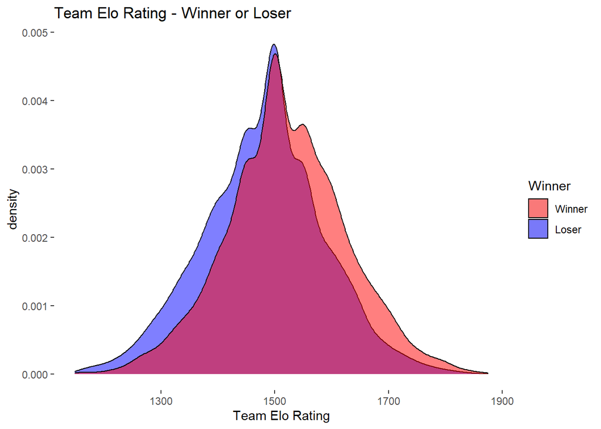

```r
plot_data <- use_data[, c(12:29, 31:52, 54:72)] # Set plot data
plot_data$winner <- as.factor(plot_data$winner) # Transform winner to factor

g_1 <- ggplot(plot_data, aes(x = elo, fill = winner)) +
  geom_density(alpha = 0.5) + # Select density plot and set transparency (alpha)
  theme_set(theme_bw(base_size = 10) ) + # Change font sizes
  theme(panel.grid.major = element_blank(), # Remove grid
        panel.grid.minor = element_blank(), # Remove grid
        panel.border = element_blank(), # Remove grid
        panel.background = element_blank()) + # Remove grid
  labs(x = "Team Elo Rating", title = "Team Elo Rating - Winner or Loser",
       fill = "Winner") + # Set labels
  scale_fill_manual(values = c("1" = "red", "0" = "blue"), # Set fill colors manually
                    labels = c("1" = "Winner", "0" = "Loser")) # Set labels for fill
g_1 # Generate plot
```

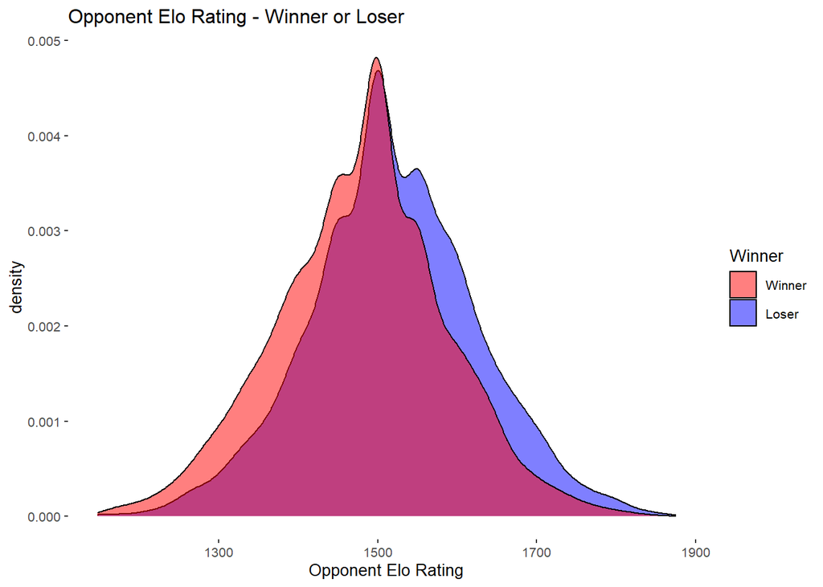

```r
g_2 <- ggplot(plot_data, aes(x = opp_elo, fill = winner)) +
  geom_density(alpha = 0.5) + # Select density plot and set transparency (alpha)
  theme_set(theme_bw(base_size = 10) ) + # Change font sizes
  theme(panel.grid.major = element_blank(), # Remove grid
        panel.grid.minor = element_blank(), # Remove grid
        panel.border = element_blank(), # Remove grid
        panel.background = element_blank()) + # Remove grid
  labs(x = "Opponent Elo Rating", title = "Opponent Elo Rating - Winner or Loser",
       fill = "Winner") + # Set labels
  scale_fill_manual(values = c("1" = "red", "0" = "blue"), # Set fill colors manually
                    labels = c("1" = "Winner", "0" = "Loser")) # Set labels for fill
g_2 # Generate plot
```

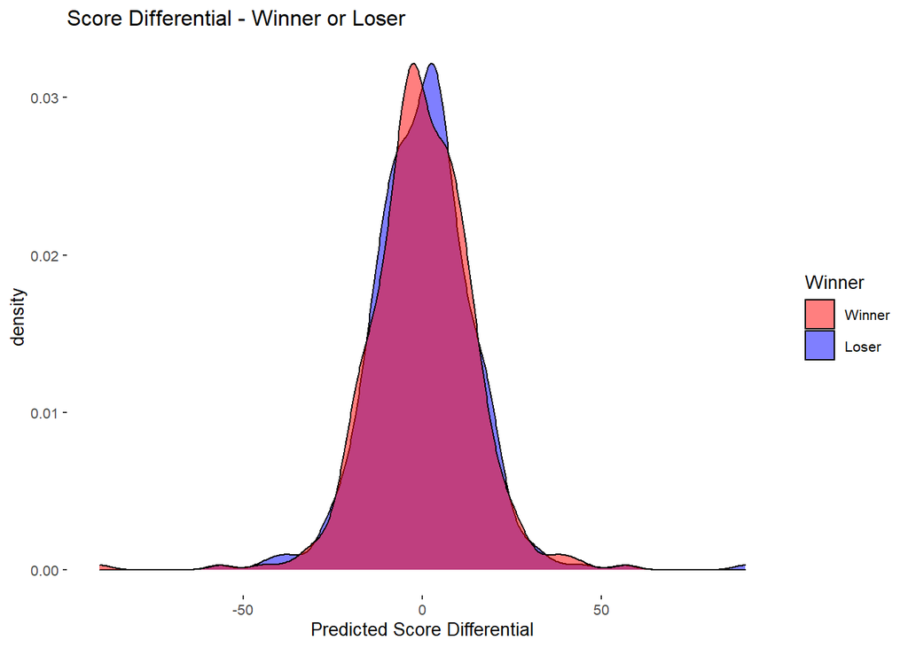

```r
g_3 <- ggplot(plot_data, aes(x = predicted_score, fill = winner)) +
  geom_density(alpha = 0.5) + # Select density plot and set transparency (alpha)
  theme_set(theme_bw(base_size = 10) ) + # Change font sizes
  theme(panel.grid.major = element_blank(), # Remove grid
        panel.grid.minor = element_blank(), # Remove grid
        panel.border = element_blank(), # Remove grid
        panel.background = element_blank()) + # Remove grid
  labs(x = "Predicted Score Differential", title = "Score Differential - Winner or Loser",
       fill = "Winner") + # Set labels
  scale_fill_manual(values = c("1" = "red", "0" = "blue"), # Set fill colors manually
                    labels = c("1" = "Winner", "0" = "Loser")) # Set labels for fill
g_3 # Generate plot
```

## Segmenting the Dataset

```r
# Segment based on index 300
train_dat <- use_data[use_data$index < 300, ]

test_dat <- use_data[use_data$index >= 300, ]

nrow(train_dat)
```

```
[1] 8398
```

```r
nrow(test_dat)
```

```
[1] 1336
```

This is a reasonable split, with 8398 observations in the training data and 1336 in the test data.

## Preparing Data for XGBoost

```r
dtrain <- xgb.DMatrix(data = as.matrix(train_dat[, c(12:29, 31:51, 54:72)]), label = as.numeric(train_dat$winner) - 1)

dtest <- xgb.DMatrix(data = as.matrix(test_dat[, c(12:29, 31:51, 54:72)]), label = as.numeric(test_dat$winner) - 1)
```

To initiate our XGBoost modeling process, we created the dtrain and dtest numeric matrices to store our training and test datasets, respectively. In creating these objects, we filtered out the first 11 columns from train_dat and test_dat, removing the initial point differential and winner columns along with a number of counterproductive variables tracking logistical information for each game. We also selectively skipped over the categorical team_opp column, containing the name of each opposing team, and the two final response variable columns (winner and point_diff). At this point, deciding to pursue a classification approach, we selected the recently omitted winner column as our response variable. Hence, point differential would no longer serve as a response variable or predictor in our models.

## Tuning the Number of Trees

```r
# Use xgb.cv to run cross-validation inside xgboost
set.seed(111111)
bst <- xgb.cv(data = dtrain, # Set training data

              nfold = 5, # Use 5 fold cross-validation

               eta = 0.1, # Set learning rate

               nrounds = 1000, # Set number of rounds
               early_stopping_rounds = 50, # Set number of rounds to stop at if there is no improvement

               verbose = 1, # 1 - Prints out fit
               nthread = 6, # Set number of parallel threads
               print_every_n = 20, # Prints out result every 20th iteration

               objective = "binary:logistic", # Set objective
               eval_metric = "auc",
               eval_metric = "error") # Set evaluation metric to use
```

```
Multiple eval metrics are present. Will use test_error for early stopping.
Will train until test_error hasn't improved in 50 rounds.

Stopping. Best iteration:
```

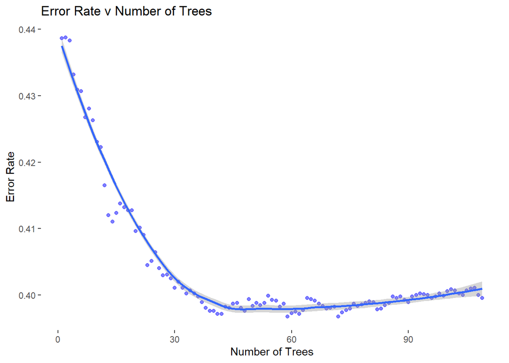

```r
g_1 <- ggplot(bst$evaluation_log, aes(x = iter, y = test_error_mean)) +
  geom_point(alpha = 0.5, color = "blue") +
  geom_smooth() +
  theme_bw() +
  theme(panel.grid.major = element_blank(),
        panel.grid.minor = element_blank(),
        panel.border = element_blank(),
        panel.background = element_blank()) +
  labs(x = "Number of Trees", title = "Error Rate v Number of Trees",
       y = "Error Rate")
g_1
```

With 59 iterations minimizing the the validation error rate at 0.397, we chose to set early_stopping_rounds at 60 for the next tuning steps.

## Tuning Max Depth and Min Child Weight

```r
max_depth_vals <- c(3, 5, 7, 10, 15) # Create vector of max depth values
min_child_weight <- c(1,3,5,7, 10, 15) # Create vector of min child values

# Expand grid of parameter values
cv_params <- expand.grid(max_depth_vals, min_child_weight)
names(cv_params) <- c("max_depth", "min_child_weight")
# Create results vector
auc_vec <- error_vec <- rep(NA, nrow(cv_params))
# Loop through results
for(i in 1:nrow(cv_params)){
  set.seed(111111)
  bst_tune <- xgb.cv(data = dtrain, # Set training data

              nfold = 5, # Use 5 fold cross-validation

              eta = 0.1, # Set learning rate
              max.depth = cv_params$max_depth[i], # Set max depth
              min_child_weight = cv_params$min_child_weight[i], # Set minimum number of samples in node to split


              nrounds = 100, # Set number of rounds
              early_stopping_rounds = 60, # Set number of rounds to stop at if there is no improvement

              verbose = 1, # 1 - Prints out fit
              nthread = 6, # Set number of parallel threads
              print_every_n = 20, # Prints out result every 20th iteration

              objective = "binary:logistic", # Set objective
              eval_metric = "auc", # Set evaluation metric to use
              eval_metric = "error") # Set evaluation metric to use
  auc_vec[i] <- bst_tune$evaluation_log$test_auc_mean[bst_tune$best_ntreelimit]
  error_vec[i] <- bst_tune$evaluation_log$test_error_mean[bst_tune$best_ntreelimit]

}
```

[output not shown]

[output cut: 52 more lines]

[output not shown]

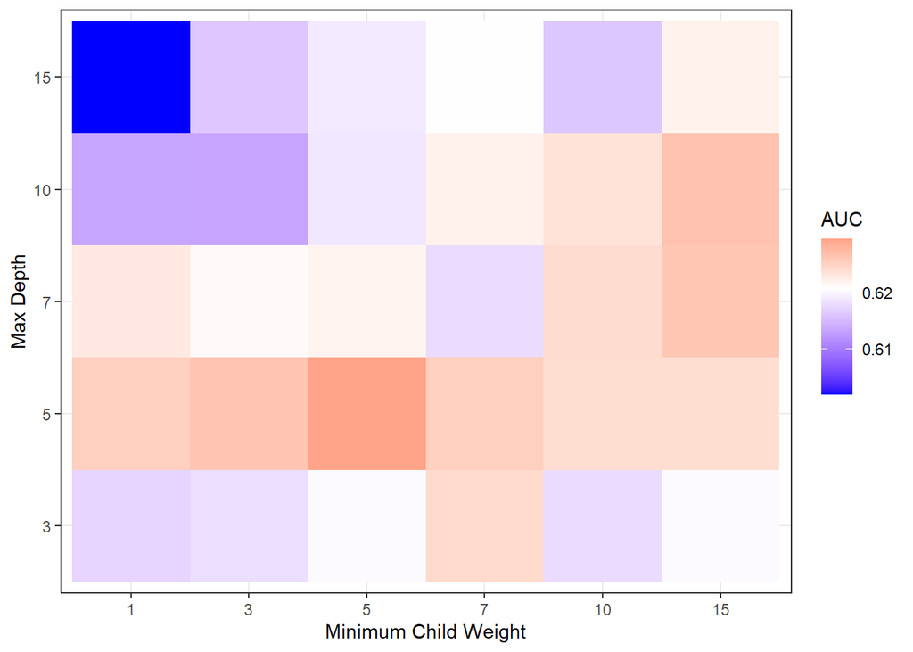

```r
# Join results in dataset
res_db <- cbind.data.frame(cv_params, auc_vec, error_vec)
names(res_db)[3:4] <- c("auc", "error")
res_db$max_depth <- as.factor(res_db$max_depth) # Convert tree number to factor for plotting
res_db$min_child_weight <- as.factor(res_db$min_child_weight) # Convert node size to factor for plotting
# Print AUC heatmap
g_2 <- ggplot(res_db, aes(y = max_depth, x = min_child_weight, fill = auc)) + # set aesthetics
  geom_tile() + # Use geom_tile for heatmap
  theme_bw() + # Set theme
  scale_fill_gradient2(low = "blue", # Choose low color
    mid = "white", # Choose mid color
    high = "red", # Choose high color
    midpoint =mean(res_db$auc), # Choose mid point
    space = "Lab",
    na.value ="grey", # Choose NA value
    guide = "colourbar", # Set color bar
    aesthetics = "fill") + # Select aesthetics to apply
  labs(x = "Minimum Child Weight", y = "Max Depth", fill = "AUC") # Set labels
g_2 # Generate plot
```

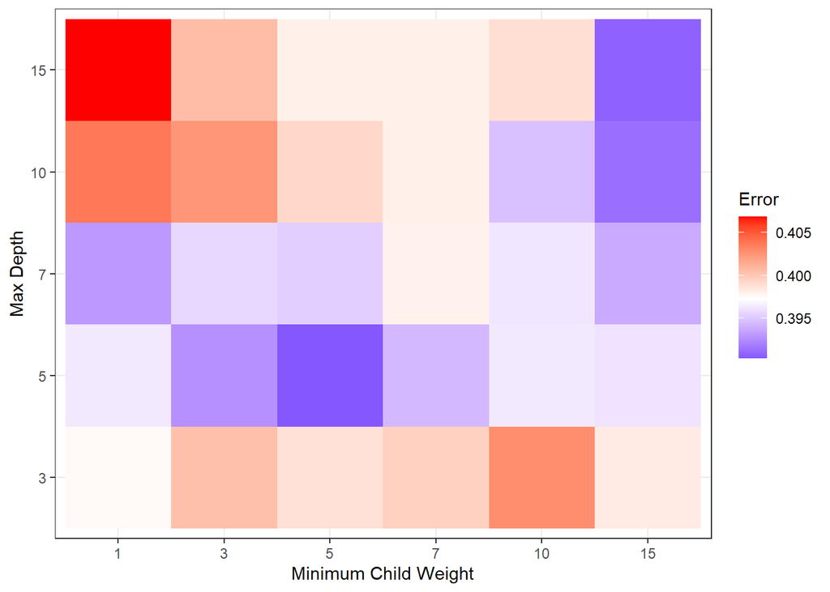

```r
# print error heatmap
g_3 <- ggplot(res_db, aes(y = max_depth, x = min_child_weight, fill = error)) + # set aesthetics
  geom_tile() + # Use geom_tile for heatmap
  theme_bw() + # Set theme
  scale_fill_gradient2(low = "blue", # Choose low color
    mid = "white", # Choose mid color
    high = "red", # Choose high color
    midpoint =mean(res_db$error), # Choose mid point
    space = "Lab",
    na.value ="grey", # Choose NA value
    guide = "colourbar", # Set color bar
    aesthetics = "fill") + # Select aesthetics to apply
  labs(x = "Minimum Child Weight", y = "Max Depth", fill = "Error") # Set labels
g_3 # Generate plot
```

```r
res_db
```

```
   max_depth min_child_weight       auc     error
1          3                1 0.6174426 0.3975950
2          5                1 0.6255234 0.3964046
3          7                1 0.6229998 0.3930708
4         10                1 0.6135460 0.4037882
5         15                1 0.6018910 0.4068832
6          3                3 0.6181244 0.4004526
7          5                3 0.6264768 0.3927140
8          7                3 0.6212628 0.3956904
9         10                3 0.6135068 0.4024770
10        15                3 0.6162652 0.4005736
11         3                5 0.6204434 0.3987846
12         5                5 0.6296642 0.3903316
13         7                5 0.6218768 0.3953324
14        10                5 0.6188616 0.3992618
```

[output cut: 16 more lines]

Employing a max depth of 5 and minimum child weight of 5 yielded the optimal combination of high validation AUC (0.630) and low validation error (0.390). Thus, we set both max_depth and min_child_weight to 5 in the following tuning steps.

## Tuning Gamma

```r
gamma_vals <- c(0, 0.05, 0.1, 0.15, 0.2) # Create vector of gamma values

# Be Careful - This can take a very long time to run
set.seed(111111)
auc_vec <- error_vec <- rep(NA, length(gamma_vals))
for(i in 1:length(gamma_vals)){
  bst_tune <- xgb.cv(data = dtrain, # Set training data

              nfold = 5, # Use 5 fold cross-validation

              eta = 0.1, # Set learning rate
              max.depth = 5, # Set max depth
              min_child_weight = 5, # Set minimum number of samples in node to split
              gamma = gamma_vals[i], # Set minimum loss reduction for split



              nrounds = 100, # Set number of rounds
              early_stopping_rounds = 60, # Set number of rounds to stop at if there is no improvement

              verbose = 1, # 1 - Prints out fit
              nthread = 1, # Set number of parallel threads
              print_every_n = 20, # Prints out result every 20th iteration

              objective = "binary:logistic", # Set objective
              eval_metric = "auc", # Set evaluation metric to use
              eval_metric = "error") # Set evaluation metric to use
  auc_vec[i] <- bst_tune$evaluation_log$test_auc_mean[bst_tune$best_ntreelimit]
  error_vec[i] <- bst_tune$evaluation_log$test_error_mean[bst_tune$best_ntreelimit]

}
```

```
Multiple eval metrics are present. Will use test_error for early stopping.
Will train until test_error hasn't improved in 60 rounds.

Multiple eval metrics are present. Will use test_error for early stopping.
Will train until test_error hasn't improved in 60 rounds.

Multiple eval metrics are present. Will use test_error for early stopping.
Will train until test_error hasn't improved in 60 rounds.

Multiple eval metrics are present. Will use test_error for early stopping.
Will train until test_error hasn't improved in 60 rounds.

Multiple eval metrics are present. Will use test_error for early stopping.
Will train until test_error hasn't improved in 60 rounds.
```

```r
# Join gamma to values
cbind.data.frame(gamma_vals, auc_vec, error_vec)
```

```
  gamma_vals   auc_vec error_vec
1       0.00 0.6296642 0.3903316
2       0.05 0.6308862 0.3916438
3       0.10 0.6338760 0.3865220
4       0.15 0.6244432 0.3955710
5       0.20 0.6315478 0.3877128
```

A gamma value of 0.1 yielded both the lowest validation error rate (0.387) and the highest validation AUC (0.634). Hence, we set gamma to 0.1 for the rest of our tuning process.

## Tuning the Number of Trees (Given New Hyperparameter Values)

```r
# Use xgb.cv to run cross-validation inside xgboost
set.seed(111111)
bst <- xgb.cv(data = dtrain, # Set training data

              nfold = 5, # Use 5 fold cross-validation

              eta = 0.1, # Set learning rate
              max.depth = 5, # Set max depth
              min_child_weight = 5, # Set minimum number of samples in node to split
              gamma = 0.1, # Set minimum loss reduction for split


              nrounds = 1000, # Set number of rounds
              early_stopping_rounds = 60, # Set number of rounds to stop at if there is no improvement

              verbose = 1, # 1 - Prints out fit
              nthread = 6, # Set number of parallel threads
              print_every_n = 20, # Prints out result every 20th iteration

              objective = "binary:logistic", # Set objective
              eval_metric = "auc",
              eval_metric = "error") # Set evaluation metric to use
```

```
Multiple eval metrics are present. Will use test_error for early stopping.
Will train until test_error hasn't improved in 60 rounds.

Stopping. Best iteration:
```

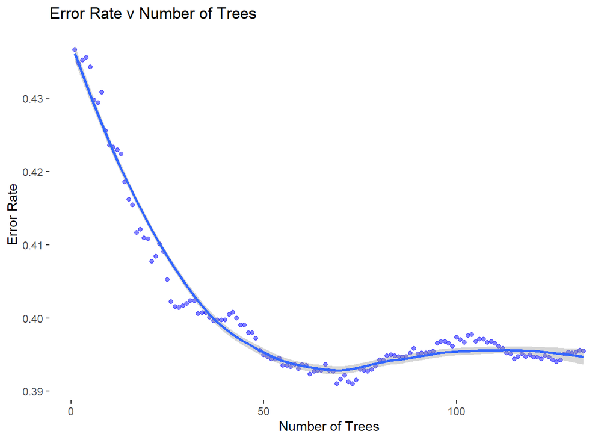

```r
g_2 <- ggplot(bst$evaluation_log, aes(x = iter, y = test_error_mean)) +
  geom_point(alpha = 0.5, color = "blue") +
  geom_smooth() +
  theme_bw() +
  theme(panel.grid.major = element_blank(),
        panel.grid.minor = element_blank(),
        panel.border = element_blank(),
        panel.background = element_blank()) +
  labs(x = "Number of Trees", title = "Error Rate v Number of Trees",
       y = "Error Rate")
g_2
```

With 73 iterations minimizing the validation error rate at 0.391, we chose to set early_stopping_rounds at 75 for the few remaining tuning steps.

## Tuning the Subsample and Column Sample

```r
subsample <- c(0.6, 0.7, 0.8, 0.9, 1) # Create vector of subsample values
colsample_by_tree <- c(0.6, 0.7, 0.8, 0.9, 1) # Create vector of col sample values

# Expand grid of tuning parameters
cv_params <- expand.grid(subsample, colsample_by_tree)
names(cv_params) <- c("subsample", "colsample_by_tree")
# Create vectors to store results
auc_vec <- error_vec <- rep(NA, nrow(cv_params))
# Loop through parameter values
for(i in 1:nrow(cv_params)){
  set.seed(111111)
  bst_tune <- xgb.cv(data = dtrain, # Set training data

              nfold = 5, # Use 5 fold cross-validation

              eta = 0.1, # Set learning rate
              max.depth = 5, # Set max depth
              min_child_weight = 5, # Set minimum number of samples in node to split
              gamma = 0.1, # Set minimum loss reduction for split
              subsample = cv_params$subsample[i], # Set proportion of training data to use in tree
              colsample_bytree = cv_params$colsample_by_tree[i], # Set number of variables to use in each tree

              nrounds = 100, # Set number of rounds
              early_stopping_rounds = 75, # Set number of rounds to stop at if there is no improvement

              verbose = 1, # 1 - Prints out fit
              nthread = 6, # Set number of parallel threads
              print_every_n = 20, # Prints out result every 20th iteration

              objective = "binary:logistic", # Set objective
              eval_metric = "auc", # Set evaluation metric to use
              eval_metric = "error") # Set evaluation metric to use
  auc_vec[i] <- bst_tune$evaluation_log$test_auc_mean[bst_tune$best_ntreelimit]
  error_vec[i] <- bst_tune$evaluation_log$test_error_mean[bst_tune$best_ntreelimit]

}
```

[output not shown]

[output cut: 19 more lines]

[output not shown]

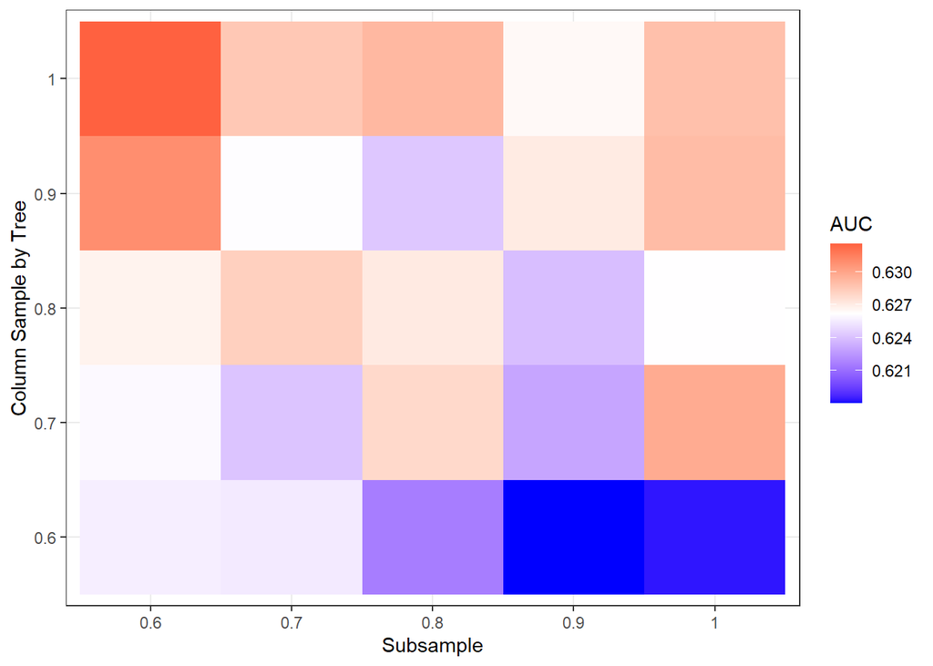

```r
res_db <- cbind.data.frame(cv_params, auc_vec, error_vec)
names(res_db)[3:4] <- c("auc", "error")
res_db$subsample <- as.factor(res_db$subsample) # Convert tree number to factor for plotting
res_db$colsample_by_tree <- as.factor(res_db$colsample_by_tree) # Convert node size to factor for plotting
g_4 <- ggplot(res_db, aes(y = colsample_by_tree, x = subsample, fill = auc)) + # set aesthetics
  geom_tile() + # Use geom_tile for heatmap
  theme_bw() + # Set theme
  scale_fill_gradient2(low = "blue", # Choose low color
    mid = "white", # Choose mid color
    high = "red", # Choose high color
    midpoint =mean(res_db$auc), # Choose mid point
    space = "Lab",
    na.value ="grey", # Choose NA value
    guide = "colourbar", # Set color bar
    aesthetics = "fill") + # Select aesthetics to apply
  labs(x = "Subsample", y = "Column Sample by Tree", fill = "AUC") # Set labels
g_4 # Generate plot
```

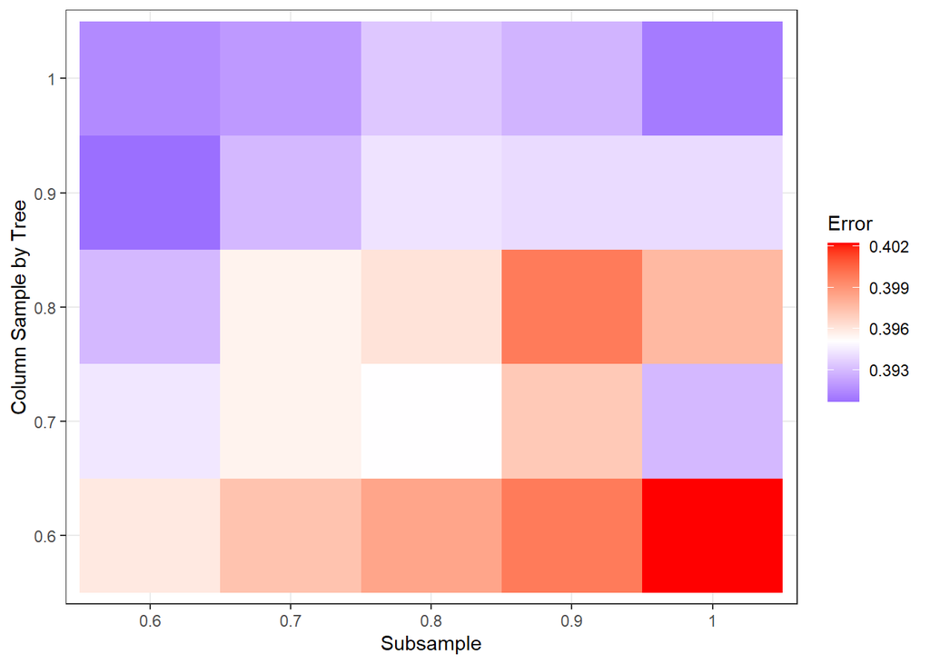

```r
g_5 <- ggplot(res_db, aes(y = colsample_by_tree, x = subsample, fill = error)) + # set aesthetics
  geom_tile() + # Use geom_tile for heatmap
  theme_bw() + # Set theme
  scale_fill_gradient2(low = "blue", # Choose low color
    mid = "white", # Choose mid color
    high = "red", # Choose high color
    midpoint =mean(res_db$error), # Choose mid point
    space = "Lab",
    na.value ="grey", # Choose NA value
    guide = "colourbar", # Set color bar
    aesthetics = "fill") + # Select aesthetics to apply
  labs(x = "Subsample", y = "Column Sample by Tree", fill = "Error") # Set labels
g_5 # Generate plot
```

```r
res_db
```

```
   subsample colsample_by_tree       auc     error
1        0.6               0.6 0.6256388 0.3959272
2        0.7               0.6 0.6254804 0.3973560
3        0.8               0.6 0.6216166 0.3984274
4        0.9               0.6 0.6180630 0.3998566
5          1               0.6 0.6183630 0.4022390
6        0.6               0.7 0.6260056 0.3943794
7        0.7               0.7 0.6241490 0.3955698
8        0.8               0.7 0.6278518 0.3950936
9        0.9               0.7 0.6230554 0.3971182
10         1               0.7 0.6297676 0.3929516
11       0.6               0.8 0.6267288 0.3929508
12       0.7               0.8 0.6282294 0.3955700
13       0.8               0.8 0.6271074 0.3961660
14       0.9               0.8 0.6239482 0.3998572
15         1               0.8 0.6261876 0.3977142
16       0.6               0.9 0.6309060 0.3906894
17       0.7               0.9 0.6261476 0.3929504
18       0.8               0.9 0.6242628 0.3942616
19       0.9               0.9 0.6270828 0.3940232
20         1               0.9 0.6290736 0.3940224
21       0.6                 1 0.6325476 0.3915218
22       0.7                 1 0.6285570 0.3919976
23       0.8                 1 0.6292130 0.3934270
24       0.9                 1 0.6264622 0.3928310
25         1                 1 0.6288808 0.3910458
```

## Tuning ETA

```r
# Use xgb.cv to run cross-validation inside xgboost
set.seed(111111)
bst_mod_1 <- xgb.cv(data = dtrain, # Set training data

              nfold = 5, # Use 5 fold cross-validation

              eta = 0.3, # Set learning rate
              max.depth = 5, # Set max depth
              min_child_weight = 5, # Set minimum number of samples in node to split
              gamma = 0.1, # Set minimum loss reduction for split
              subsample = 0.6, # Set proportion of training data to use in tree
              colsample_bytree =  1, # Set number of variables to use in each tree

              nrounds = 1000, # Set number of rounds
              early_stopping_rounds = 75, # Set number of rounds to stop at if there is no improvement

              verbose = 1, # 1 - Prints out fit
              nthread = 6, # Set number of parallel threads
              print_every_n = 20, # Prints out result every 20th iteration

              objective = "binary:logistic", # Set objective
              eval_metric = "auc",
              eval_metric = "error") # Set evaluation metric to use
```

```
Multiple eval metrics are present. Will use test_error for early stopping.
Will train until test_error hasn't improved in 75 rounds.

Stopping. Best iteration:
```

```r
set.seed(111111)
bst_mod_2 <- xgb.cv(data = dtrain, # Set training data

              nfold = 5, # Use 5 fold cross-validation

              eta = 0.1, # Set learning rate
              max.depth =  5, # Set max depth
              min_child_weight = 5, # Set minimum number of samples in node to split
              gamma = 0.1, # Set minimum loss reduction for split
              subsample = 0.6 , # Set proportion of training data to use in tree
              colsample_bytree = 1, # Set number of variables to use in each tree

              nrounds = 1000, # Set number of rounds
              early_stopping_rounds = 75, # Set number of rounds to stop at if there is no improvement

              verbose = 1, # 1 - Prints out fit
              nthread = 6, # Set number of parallel threads
              print_every_n = 20, # Prints out result every 20th iteration

              objective = "binary:logistic", # Set objective
              eval_metric = "auc",
              eval_metric = "error") # Set evaluation metric to use
```

```
Multiple eval metrics are present. Will use test_error for early stopping.
Will train until test_error hasn't improved in 75 rounds.

Stopping. Best iteration:
```

```r
set.seed(111111)
bst_mod_3 <- xgb.cv(data = dtrain, # Set training data

              nfold = 5, # Use 5 fold cross-validation

              eta = 0.05, # Set learning rate
              max.depth = 5, # Set max depth
              min_child_weight = 5, # Set minimum number of samples in node to split
              gamma = 0.1, # Set minimum loss reduction for split
              subsample = 0.6 , # Set proportion of training data to use in tree
              colsample_bytree =  1, # Set number of variables to use in each tree

              nrounds = 1000, # Set number of rounds
              early_stopping_rounds = 75, # Set number of rounds to stop at if there is no improvement

              verbose = 1, # 1 - Prints out fit
              nthread = 6, # Set number of parallel threads
              print_every_n = 20, # Prints out result every 20th iteration

              objective = "binary:logistic", # Set objective
              eval_metric = "auc",
              eval_metric = "error") # Set evaluation metric to use
```

```
Multiple eval metrics are present. Will use test_error for early stopping.
Will train until test_error hasn't improved in 75 rounds.

Stopping. Best iteration:
```

```r
set.seed(111111)
bst_mod_4 <- xgb.cv(data = dtrain, # Set training data

              nfold = 5, # Use 5 fold cross-validation

              eta = 0.01, # Set learning rate
              max.depth = 5, # Set max depth
              min_child_weight = 5, # Set minimum number of samples in node to split
              gamma = 0.1, # Set minimum loss reduction for split
              subsample = 0.6, # Set proportion of training data to use in tree
              colsample_bytree = 1, # Set number of variables to use in each tree

              nrounds = 1000, # Set number of rounds
              early_stopping_rounds = 75, # Set number of rounds to stop at if there is no improvement

              verbose = 1, # 1 - Prints out fit
              nthread = 6, # Set number of parallel threads
              print_every_n = 20, # Prints out result every 20th iteration

              objective = "binary:logistic", # Set objective
              eval_metric = "auc",
              eval_metric = "error") # Set evaluation metric to use
```

```
Multiple eval metrics are present. Will use test_error for early stopping.
Will train until test_error hasn't improved in 75 rounds.

Stopping. Best iteration:
```

```r
set.seed(111111)
bst_mod_5 <- xgb.cv(data = dtrain, # Set training data

              nfold = 5, # Use 5 fold cross-validation

              eta = 0.005, # Set learning rate
              max.depth = 5, # Set max depth
              min_child_weight = 5, # Set minimum number of samples in node to split
              gamma = 0.1, # Set minimum loss reduction for split
              subsample = 0.6, # Set proportion of training data to use in tree
              colsample_bytree = 1, # Set number of variables to use in each tree

              nrounds = 1000, # Set number of rounds
              early_stopping_rounds = 75, # Set number of rounds to stop at if there is no improvement

              verbose = 1, # 1 - Prints out fit
              nthread = 6, # Set number of parallel threads
              print_every_n = 20, # Prints out result every 20th iteration

              objective = "binary:logistic", # Set objective
              eval_metric = "auc",
              eval_metric = "error") # Set evaluation metric to use
```

```
Multiple eval metrics are present. Will use test_error for early stopping.
Will train until test_error hasn't improved in 75 rounds.

Stopping. Best iteration:
```

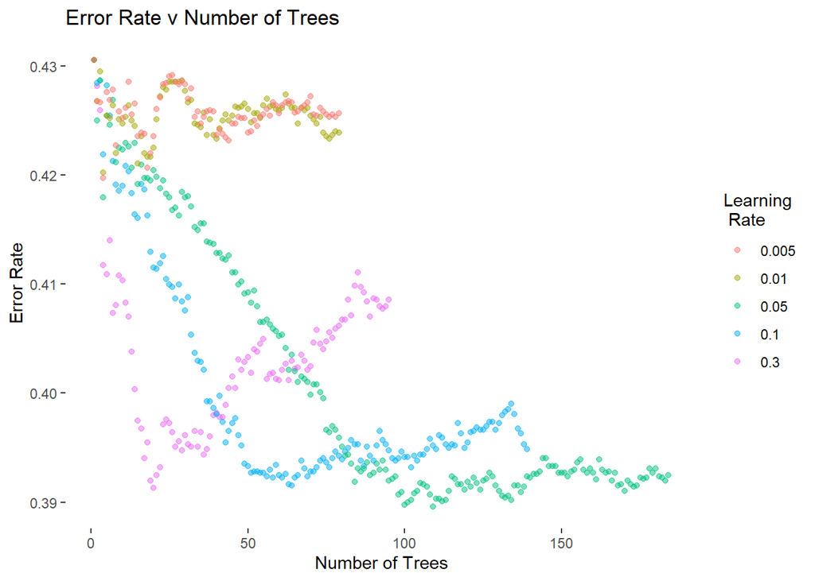

```r
# Extract results for model with eta = 0.3
pd1 <- cbind.data.frame(bst_mod_1$evaluation_log[,c("iter", "test_error_mean")], rep(0.3, nrow(bst_mod_1$evaluation_log)))
names(pd1)[3] <- "eta"
# Extract results for model with eta = 0.1
pd2 <- cbind.data.frame(bst_mod_2$evaluation_log[,c("iter", "test_error_mean")], rep(0.1, nrow(bst_mod_2$evaluation_log)))
names(pd2)[3] <- "eta"
# Extract results for model with eta = 0.05
pd3 <- cbind.data.frame(bst_mod_3$evaluation_log[,c("iter", "test_error_mean")], rep(0.05, nrow(bst_mod_3$evaluation_log)))
names(pd3)[3] <- "eta"
# Extract results for model with eta = 0.01
pd4 <- cbind.data.frame(bst_mod_4$evaluation_log[,c("iter", "test_error_mean")], rep(0.01, nrow(bst_mod_4$evaluation_log)))
names(pd4)[3] <- "eta"
# Extract results for model with eta = 0.005
pd5 <- cbind.data.frame(bst_mod_5$evaluation_log[,c("iter", "test_error_mean")], rep(0.005, nrow(bst_mod_5$evaluation_log)))
names(pd5)[3] <- "eta"
# Join datasets
plot_data <- rbind.data.frame(pd1, pd2, pd3, pd4, pd5)
# Converty ETA to factor
plot_data$eta <- as.factor(plot_data$eta)
# Plot points
g_6 <- ggplot(plot_data, aes(x = iter, y = test_error_mean, color = eta))+
  geom_point(alpha = 0.5) +
  theme_bw() + # Set theme
  theme(panel.grid.major = element_blank(), # Remove grid
        panel.grid.minor = element_blank(), # Remove grid
        panel.border = element_blank(), # Remove grid
        panel.background = element_blank()) + # Remove grid
  labs(x = "Number of Trees", title = "Error Rate v Number of Trees",
       y = "Error Rate", color = "Learning \n Rate")  # Set labels
g_6
```

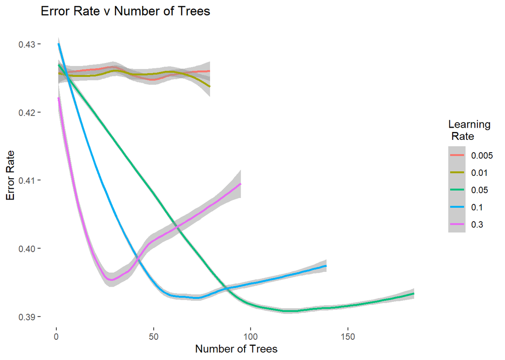

```r
# Plot lines
g_7 <- ggplot(plot_data, aes(x = iter, y = test_error_mean, color = eta))+
  geom_smooth(alpha = 0.5) +
  theme_bw() + # Set theme
  theme(panel.grid.major = element_blank(), # Remove grid
        panel.grid.minor = element_blank(), # Remove grid
        panel.border = element_blank(), # Remove grid
        panel.background = element_blank()) + # Remove grid
  labs(x = "Number of Trees", title = "Error Rate v Number of Trees",
       y = "Error Rate", color = "Learning \n Rate")  # Set labels
g_7
```

Given this chart and the previous model output, it appears that utilizing an ETA value of 0.05 with 109 trees minimzes the validation error rate at about 0.390. Thus, we chose to set ETA at 0.05 and nrounds/early_stopping_rounds at 109 for our final model.

## Running the Final Model

```r
set.seed(111111)
bst_final <- xgboost(data = dtrain, # Set training data

              eta = 0.05, # Set learning rate
              max.depth =  5, # Set max depth
              min_child_weight = 5, # Set minimum number of samples in node to split
              gamma = 0.1, # Set minimum loss reduction for split
              subsample =  0.6, # Set proportion of training data to use in tree
              colsample_bytree = 1, # Set number of variables to use in each tree

              nrounds = 109, # Set number of rounds
              early_stopping_rounds = 109, # Set number of rounds to stop at if there is no improvement

              verbose = 1, # 1 - Prints out fit
              nthread = 6, # Set number of parallel threads
              print_every_n = 20, # Prints out result every 20th iteration

              objective = "binary:logistic", # Set objective
              eval_metric = "auc",
              eval_metric = "error") # Set evaluation metric to use
```

```
Multiple eval metrics are present. Will use train_error for early stopping.
Will train until train_error hasn't improved in 109 rounds.
```

```r
boost_preds <- predict(bst_final, dtrain) # Create predictions for XGBoost model on training data

pred_dat <- cbind.data.frame(boost_preds , train_dat$winner)#
names(pred_dat) <- c("predictions", "response")
oc<- optimal.cutpoints(X = "predictions",
                       status = "response",
                       tag.healthy = 0,
                       data = pred_dat,
                       methods = "MaxEfficiency")

boost_preds <- predict(bst_final, dtest) # Create predictions for XGBoost model on testing data

pred_dat <- cbind.data.frame(boost_preds , test_dat$winner)
# Convert predictions to classes, using optimal cut-off
boost_pred_class <- rep(0, length(boost_preds))
boost_pred_class[boost_preds >= oc$MaxEfficiency$Global$optimal.cutoff$cutoff[1]] <- 1


t <- table(boost_pred_class, test_dat$winner) # Create table
confusionMatrix(t, positive = "1") # Produce confusion matrix
```

```
Confusion Matrix and Statistics


boost_pred_class   0   1
               0 189 121
               1 419 607

               Accuracy : 0.5958
                 95% CI : (0.5689, 0.6223)
    No Information Rate : 0.5449
    P-Value [Acc > NIR] : 9.882e-05

                  Kappa : 0.1507

 Mcnemar's Test P-Value : < 2.2e-16

            Sensitivity : 0.8338
            Specificity : 0.3109
         Pos Pred Value : 0.5916
         Neg Pred Value : 0.6097
             Prevalence : 0.5449
         Detection Rate : 0.4543
   Detection Prevalence : 0.7680
      Balanced Accuracy : 0.5723

       'Positive' Class : 1
```

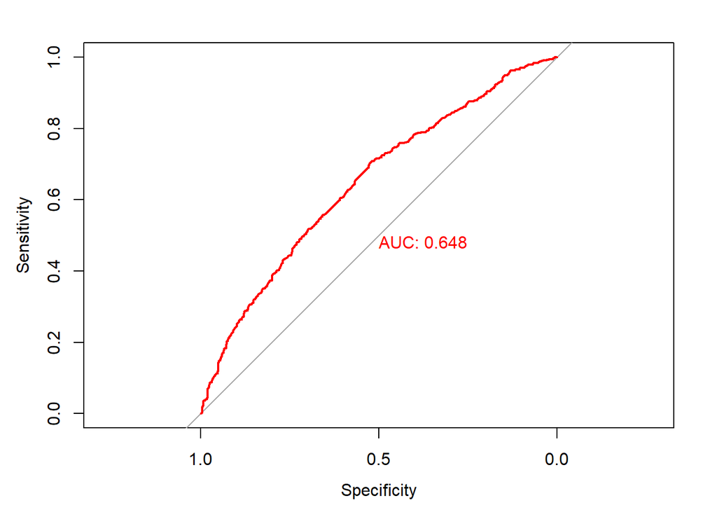

```r
# Calculate and plot final model ROC
roc1 = roc(test_dat$winner, boost_preds)
plot.roc(roc1, print.auc = TRUE, col = "red", print.auc.col = "red")
```

## Extracting Variable Importance

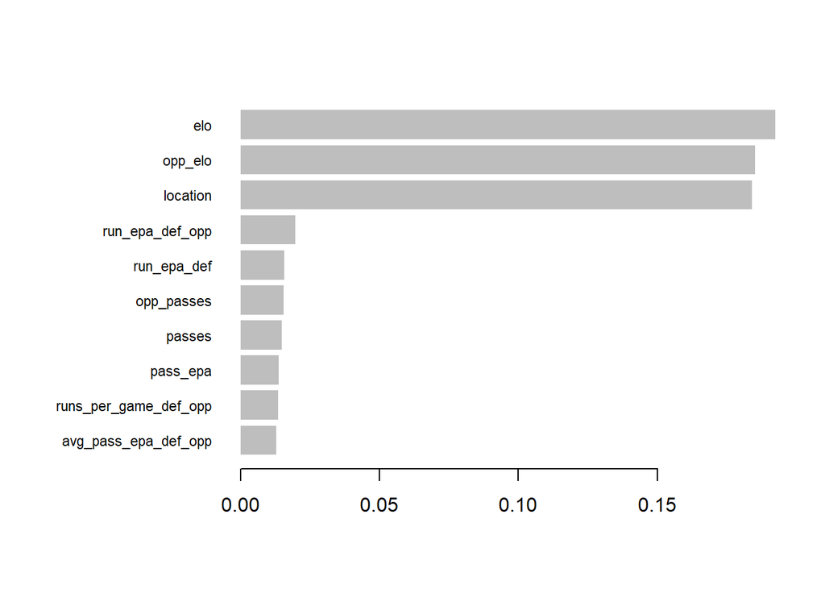

```r
# Extract importance
imp_mat <- xgb.importance(model = bst_final)
# Plot importance (top 10 variables)
xgb.plot.importance(imp_mat, top_n = 10)
```

```r
# Save graph data
write.csv(imp_mat, file = 'importance_plot.csv')
```